# MovieLens_Project_Solution_Notebook_Nidhi

### 1. Import the necessary packages - 2.5 marks

```python
import pandas as pd
import numpy as np
import matplotlib.pyplot as plt
%matplotlib inline
import seaborn as sns
from scipy import stats
```

### 2. Read the 3 datasets into dataframes - 2.5 marks

```python
#user
user = pd.read_csv('user.csv')
user.head()
```

|  | user id | age | gender | occupation | zip code |
| --- | --- | --- | --- | --- | --- |
| 0 | 1 | 24 | M | technician | 85711 |
| 1 | 2 | 53 | F | other | 94043 |
| 2 | 3 | 23 | M | writer | 32067 |
| 3 | 4 | 24 | M | technician | 43537 |
| 4 | 5 | 33 | F | other | 15213 |

```python
#rating
rating=pd.read_csv('data.csv')
rating.head()
```

|  | user id | movie id | rating | timestamp |
| --- | --- | --- | --- | --- |
| 0 | 196 | 242 | 3 | 881250949 |
| 1 | 186 | 302 | 3 | 891717742 |
| 2 | 22 | 377 | 1 | 878887116 |
| 3 | 244 | 51 | 2 | 880606923 |
| 4 | 166 | 346 | 1 | 886397596 |

```python
#movie details
movie_info=pd.read_csv('item.csv')
movie_info.head()
```

|  | movie id | movie title | release date | unknown | Action | Adventure | Animation | Childrens | Comedy | Crime | ... | Fantasy | Film-Noir | Horror | Musical | Mystery | Romance | Sci-Fi | Thriller | War | Western |
| --- | --- | --- | --- | --- | --- | --- | --- | --- | --- | --- | --- | --- | --- | --- | --- | --- | --- | --- | --- | --- | --- |
| 0 | 1 | Toy Story | 01-Jan-1995 | 0 | 0 | 0 | 1 | 1 | 1 | 0 | ... | 0 | 0 | 0 | 0 | 0 | 0 | 0 | 0 | 0 | 0 |
| 1 | 2 | GoldenEye | 01-Jan-1995 | 0 | 1 | 1 | 0 | 0 | 0 | 0 | ... | 0 | 0 | 0 | 0 | 0 | 0 | 0 | 1 | 0 | 0 |
| 2 | 3 | Four Rooms | 01-Jan-1995 | 0 | 0 | 0 | 0 | 0 | 0 | 0 | ... | 0 | 0 | 0 | 0 | 0 | 0 | 0 | 1 | 0 | 0 |
| 3 | 4 | Get Shorty | 01-Jan-1995 | 0 | 1 | 0 | 0 | 0 | 1 | 0 | ... | 0 | 0 | 0 | 0 | 0 | 0 | 0 | 0 | 0 | 0 |
| 4 | 5 | Copycat | 01-Jan-1995 | 0 | 0 | 0 | 0 | 0 | 0 | 1 | ... | 0 | 0 | 0 | 0 | 0 | 0 | 0 | 1 | 0 | 0 |

5 rows × 22 columns

### 3. Apply info, shape, describe, and find the number of missing values in the data. Present at least 3 observations from these operations - 2.5 marks

- Note that you will need to do it for all the three datasets seperately

```python
#user info
user.info()
```

```
<class 'pandas.core.frame.DataFrame'>
RangeIndex: 943 entries, 0 to 942
Data columns (total 5 columns):
 #   Column      Non-Null Count  Dtype
---  ------      --------------  -----
 0   user id     943 non-null    int64
 1   age         943 non-null    int64
 2   gender      943 non-null    object
 3   occupation  943 non-null    object
 4   zip code    943 non-null    object
dtypes: int64(2), object(3)
memory usage: 37.0+ KB
```

```python
#user shape
user.shape
```

```
(943, 5)
```

```python
user.describe()
```

|  | user id | age |
| --- | --- | --- |
| count | 943.000000 | 943.000000 |
| mean | 472.000000 | 34.051962 |
| std | 272.364951 | 12.192740 |
| min | 1.000000 | 7.000000 |
| 25% | 236.500000 | 25.000000 |
| 50% | 472.000000 | 31.000000 |
| 75% | 707.500000 | 43.000000 |
| max | 943.000000 | 73.000000 |

```python
user.isnull().sum()
```

```
user id       0
age           0
gender        0
occupation    0
zip code      0
dtype: int64
```

```python
#rating
rating.info()
```

```
<class 'pandas.core.frame.DataFrame'>
RangeIndex: 100000 entries, 0 to 99999
Data columns (total 4 columns):
 #   Column     Non-Null Count   Dtype
---  ------     --------------   -----
 0   user id    100000 non-null  int64
 1   movie id   100000 non-null  int64
 2   rating     100000 non-null  int64
 3   timestamp  100000 non-null  int64
dtypes: int64(4)
memory usage: 3.1 MB
```

```python
rating.shape
```

```
(100000, 4)
```

```python
rating.describe()
```

|  | user id | movie id | rating | timestamp |
| --- | --- | --- | --- | --- |
| count | 100000.00000 | 100000.000000 | 100000.000000 | 1.000000e+05 |
| mean | 462.48475 | 425.530130 | 3.529860 | 8.835289e+08 |
| std | 266.61442 | 330.798356 | 1.125674 | 5.343856e+06 |
| min | 1.00000 | 1.000000 | 1.000000 | 8.747247e+08 |
| 25% | 254.00000 | 175.000000 | 3.000000 | 8.794487e+08 |
| 50% | 447.00000 | 322.000000 | 4.000000 | 8.828269e+08 |
| 75% | 682.00000 | 631.000000 | 4.000000 | 8.882600e+08 |
| max | 943.00000 | 1682.000000 | 5.000000 | 8.932866e+08 |

```python
rating.isnull().sum()
```

```
user id      0
movie id     0
rating       0
timestamp    0
dtype: int64
```

```python
movie_info.info()
```

```
<class 'pandas.core.frame.DataFrame'>
RangeIndex: 1681 entries, 0 to 1680
Data columns (total 22 columns):
 #   Column        Non-Null Count  Dtype
---  ------        --------------  -----
 0   movie id      1681 non-null   int64
 1   movie title   1681 non-null   object
 2   release date  1681 non-null   object
 3   unknown       1681 non-null   int64
 4   Action        1681 non-null   int64
 5   Adventure     1681 non-null   int64
 6   Animation     1681 non-null   int64
 7   Childrens     1681 non-null   int64
 8   Comedy        1681 non-null   int64
 9   Crime         1681 non-null   int64
 10  Documentary   1681 non-null   int64
 11  Drama         1681 non-null   int64
 12  Fantasy       1681 non-null   int64
 13  Film-Noir     1681 non-null   int64
 14  Horror        1681 non-null   int64
 15  Musical       1681 non-null   int64
 16  Mystery       1681 non-null   int64
 17  Romance       1681 non-null   int64
 18  Sci-Fi        1681 non-null   int64
 19  Thriller      1681 non-null   int64
 20  War           1681 non-null   int64
 21  Western       1681 non-null   int64
dtypes: int64(20), object(2)
memory usage: 289.0+ KB
```

```python
movie_info.shape
```

```
(1681, 22)
```

```python
movie_info.describe()
```

|  | movie id | unknown | Action | Adventure | Animation | Childrens | Comedy | Crime | Documentary | Drama | Fantasy | Film-Noir | Horror | Musical | Mystery | Romance | Sci-Fi | Thriller | War | Western |
| --- | --- | --- | --- | --- | --- | --- | --- | --- | --- | --- | --- | --- | --- | --- | --- | --- | --- | --- | --- | --- |
| count | 1681.000000 | 1681.000000 | 1681.000000 | 1681.000000 | 1681.000000 | 1681.000000 | 1681.000000 | 1681.000000 | 1681.000000 | 1681.000000 | 1681.000000 | 1681.000000 | 1681.000000 | 1681.000000 | 1681.000000 | 1681.000000 | 1681.000000 | 1681.000000 | 1681.000000 | 1681.000000 |
| mean | 841.841761 | 0.000595 | 0.149316 | 0.080309 | 0.024985 | 0.072576 | 0.300416 | 0.064842 | 0.029744 | 0.431291 | 0.013087 | 0.014277 | 0.054729 | 0.033314 | 0.036288 | 0.146936 | 0.060083 | 0.149316 | 0.042237 | 0.016062 |
| std | 485.638077 | 0.024390 | 0.356506 | 0.271852 | 0.156126 | 0.259516 | 0.458576 | 0.246321 | 0.169931 | 0.495404 | 0.113683 | 0.118667 | 0.227519 | 0.179507 | 0.187061 | 0.354148 | 0.237712 | 0.356506 | 0.201189 | 0.125751 |
| min | 1.000000 | 0.000000 | 0.000000 | 0.000000 | 0.000000 | 0.000000 | 0.000000 | 0.000000 | 0.000000 | 0.000000 | 0.000000 | 0.000000 | 0.000000 | 0.000000 | 0.000000 | 0.000000 | 0.000000 | 0.000000 | 0.000000 | 0.000000 |
| 25% | 422.000000 | 0.000000 | 0.000000 | 0.000000 | 0.000000 | 0.000000 | 0.000000 | 0.000000 | 0.000000 | 0.000000 | 0.000000 | 0.000000 | 0.000000 | 0.000000 | 0.000000 | 0.000000 | 0.000000 | 0.000000 | 0.000000 | 0.000000 |
| 50% | 842.000000 | 0.000000 | 0.000000 | 0.000000 | 0.000000 | 0.000000 | 0.000000 | 0.000000 | 0.000000 | 0.000000 | 0.000000 | 0.000000 | 0.000000 | 0.000000 | 0.000000 | 0.000000 | 0.000000 | 0.000000 | 0.000000 | 0.000000 |
| 75% | 1262.000000 | 0.000000 | 0.000000 | 0.000000 | 0.000000 | 0.000000 | 1.000000 | 0.000000 | 0.000000 | 1.000000 | 0.000000 | 0.000000 | 0.000000 | 0.000000 | 0.000000 | 0.000000 | 0.000000 | 0.000000 | 0.000000 | 0.000000 |
| max | 1682.000000 | 1.000000 | 1.000000 | 1.000000 | 1.000000 | 1.000000 | 1.000000 | 1.000000 | 1.000000 | 1.000000 | 1.000000 | 1.000000 | 1.000000 | 1.000000 | 1.000000 | 1.000000 | 1.000000 | 1.000000 | 1.000000 | 1.000000 |

```python
movie_info.isnull().sum()
```

```
movie id        0
movie title     0
release date    0
unknown         0
Action          0
Adventure       0
Animation       0
Childrens       0
Comedy          0
Crime           0
Documentary     0
Drama           0
Fantasy         0
Film-Noir       0
Horror          0
Musical         0
Mystery         0
Romance         0
Sci-Fi          0
Thriller        0
War             0
Western         0
dtype: int64
```

**Observations:**

User:

1. Only user id and age are numeric columns.
2. There is no null values in user datasets.
3. There is some positive skeness in user age column.
4. There are few outliers for age column.

Rating:

1. there is no null values in rating dataframe.
2. While identifying skewness and outlier, we can leave user id and movie id. There is some negative skewness in rating and positive skewness in timestamp.
3. There will be few outliers.

Movie_info:

1. There is no num value in movie detail dataframe.
2. There is positive skewness in all the genre columns.

### 4. Find the number of movies per genre using the item data - 2.5 marks

```python
movie_info.columns
```

```
Index(['movie id', 'movie title', 'release date', 'unknown', 'Action',
       'Adventure', 'Animation', 'Childrens', 'Comedy', 'Crime', 'Documentary',
       'Drama', 'Fantasy', 'Film-Noir', 'Horror', 'Musical', 'Mystery',
       'Romance', 'Sci-Fi', 'Thriller', 'War', 'Western'],
      dtype='object')
```

```python
df=movie_info[['unknown', 'Action','Adventure', 'Animation', 'Childrens', 'Comedy', 'Crime', 'Documentary','Drama', 'Fantasy', 'Film-Noir', 'Horror', 'Musical', 'Mystery','Romance', 'Sci-Fi', 'Thriller', 'War', 'Western']]
```

```python
#number of movies per genre
movie_sum = df[df == 1].sum().sort_values(ascending=False)
movie_sum_df= movie_sum.to_frame()
movie_sum_df = movie_sum_df.rename(columns = {0:'Movie Count'})
movie_sum_df
```

|  | Movie Count |
| --- | --- |
| Drama | 725.0 |
| Comedy | 505.0 |
| Thriller | 251.0 |
| Action | 251.0 |
| Romance | 247.0 |
| Adventure | 135.0 |
| Childrens | 122.0 |
| Crime | 109.0 |
| Sci-Fi | 101.0 |
| Horror | 92.0 |
| War | 71.0 |
| Mystery | 61.0 |
| Musical | 56.0 |
| Documentary | 50.0 |
| Animation | 42.0 |
| Western | 27.0 |
| Film-Noir | 24.0 |
| Fantasy | 22.0 |
| unknown | 1.0 |

```python
#top 5 movie genres
movie_sum_df.head(5)
```

|  | Movie Count |
| --- | --- |
| Drama | 725.0 |
| Comedy | 505.0 |
| Thriller | 251.0 |
| Action | 251.0 |
| Romance | 247.0 |

```python
# botton 5 movie genres
movie_sum_df.tail(5)
```

|  | Movie Count |
| --- | --- |
| Animation | 42.0 |
| Western | 27.0 |
| Film-Noir | 24.0 |
| Fantasy | 22.0 |
| unknown | 1.0 |

```python
#max movie count for any genre
movie_sum_df['Movie Count'].max()
```

```
725.0
```

```python
#min movie count for any genre
movie_sum_df['Movie Count'].min()
```

```
1.0
```

**Insights:**

1. Drama has maximum movie count and unknown has only 1 movie.
2. Top 5 genres are Drama, Comedy, Thriller, Action and Romance.
3. Bottom 5 genres are Animation, Western, Film-Noir, Fantasy, unknown.
4. Max movie count is 725 and min is 1.

### 5. Drop the movie where the genre is unknown - 2.5 marks

```python
df = movie_info.drop(movie_info[movie_info['unknown'] == 1].index, inplace=False)
df.shape
```

```
(1680, 22)
```

**Insights:** There was only one movie with genre 'unknown'. Total remaining movies with genre are 1680.

### 6. Find the movies that have more than one genre - 5 marks

hint: use sum on the axis = 1

Display movie name, number of genres for the movie in dataframe

and also print(total number of movies which have more than one genres)

```python
#movies that have more than  1 genre
movie_sum = movie_info[movie_info[['unknown','Action',
       'Adventure', 'Animation', 'Childrens', 'Comedy', 'Crime', 'Documentary',
       'Drama', 'Fantasy', 'Film-Noir', 'Horror', 'Musical', 'Mystery',
       'Romance', 'Sci-Fi', 'Thriller', 'War', 'Western']] == 1].sum(axis=1).reset_index()

movie_sum.columns = ['movie_id','genre_count']
movie_ids = movie_sum[movie_sum['genre_count'] >1]
movie_ids_df = movie_info.merge(movie_ids,left_on = 'movie id', right_on = 'movie_id' )
movie_ids_df[['movie title', 'genre_count']].head()
```

|  | movie title | genre_count |
| --- | --- | --- |
| 0 | Toy Story | 3.0 |
| 1 | Four Rooms | 3.0 |
| 2 | Get Shorty | 3.0 |
| 3 | Shanghai Triad (Yao a yao yao dao waipo qiao) | 2.0 |
| 4 | Twelve Monkeys | 3.0 |

```python
# movie with maximun genres
movie_ids_df[['movie title', 'genre_count']].sort_values(by='genre_count').max()
```

```
movie title    Young Poisoner's Handbook, The
genre_count                                  6
dtype: object
```

```python
movie_ids_df[['movie title', 'genre_count']].sort_values(by='genre_count').min()
```

```
movie title    101 Dalmatians
genre_count                  2
dtype: object
```

```python
print("Total number of movies which have more than one genre \t%s" %movie_ids_df.shape[0])
```

```
Total number of movies which have more than one genre 	848
```

### 7. Univariate plots of columns: 'rating', 'Age', 'release year', 'Gender' and 'Occupation' - 10 marks

*HINT: Use distplot for age and countplot for release year, ratings,*

*HINT: Please refer to the below snippet to understand how to get to release year from release date. You can use str.split() as depicted below or you could convert it to pandas datetime format and extract year (.dt.year)*

```python
a = 'My*cat*is*brown'
print(a.split('*')[3])

#similarly, the release year needs to be taken out from release date

#also you can simply slice existing string to get the desired data, if we want to take out the colour of the cat

print(a[10:])
print(a[-5:])
```

```
brown
brown
brown
```

### univariant plot for rating

```python
rating.columns
```

```
Index(['user id', 'movie id', 'rating', 'timestamp'], dtype='object')
```

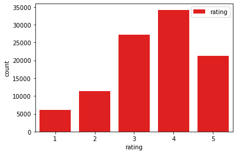

```python
sns.countplot(rating['rating'],label = 'rating', color='red');
plt.legend();
```

### Univariant Plot for Age

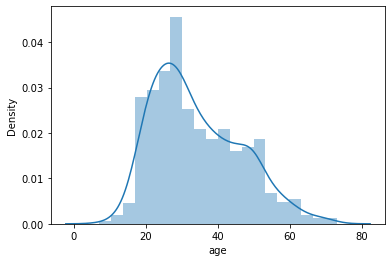

```python
sns.distplot(user['age'],bins=20);
```

### Univariant Plot for Gender

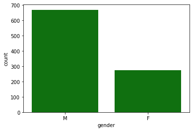

```python
sns.countplot(data=user,x='gender',color='green');
```

### Univariant Plot for occupation

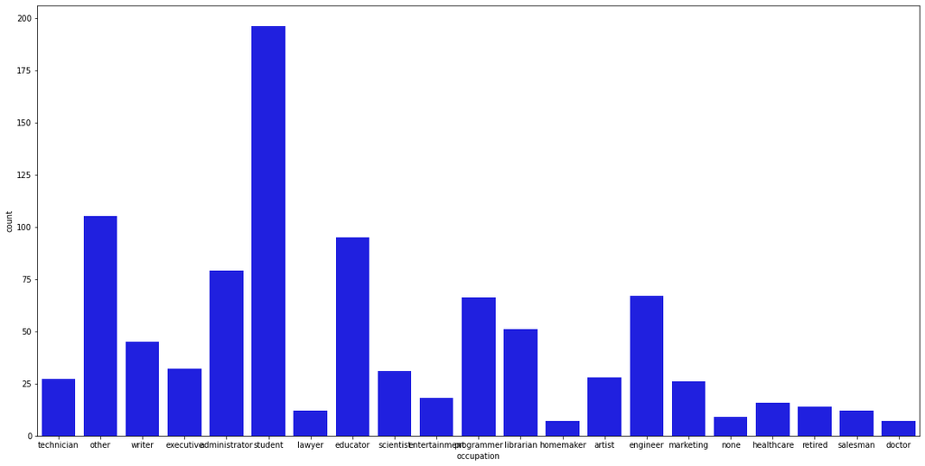

```python
plt.figure(figsize=(20,10))
sns.countplot(data=user,x='occupation',color='blue');
plt.show()
```

### Univariant plot for release year

```python
movie_info['year'] = movie_info['release date'].apply(lambda x : x.split('-')[2])  # ( or directly convert into the short form)
movie_info['year']
```

```
0       1995
1       1995
2       1995
3       1995
4       1995
        ...
1676    1998
1677    1998
1678    1998
1679    1994
1680    1996
Name: year, Length: 1681, dtype: object
```

```python
movie_info['year'].unique()
```

```
array(['1995', '1996', '1994', '1967', '1977', '1993', '1965', '1982',
       '1990', '1992', '1991', '1937', '1997', '1981', '1970', '1972',
       '1961', '1939', '1941', '1968', '1969', '1954', '1971', '1988',
       '1973', '1979', '1987', '1986', '1989', '1974', '1980', '1985',
       '1966', '1957', '1960', '1984', '1983', '1975', '1998', '1940',
       '1950', '1964', '1951', '1962', '1933', '1956', '1963', '1958',
       '1945', '1976', '1978', '1959', '1942', '1953', '1946', '1955',
       '1938', '1934', '1949', '1948', '1943', '1944', '1936', '1935',
       '1930', '1952', '1931', '1922', '1947', '1932', '1926'],
      dtype=object)
```

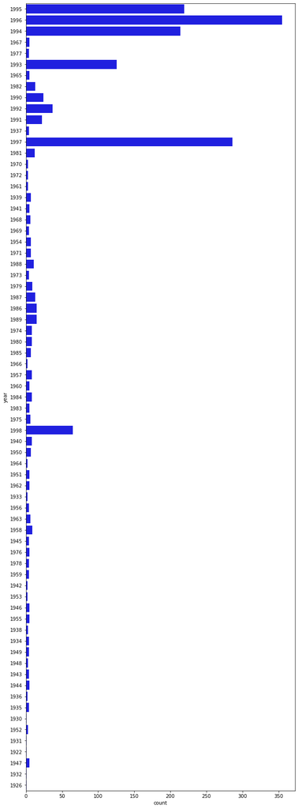

```python
plt.figure(figsize=(10,30))
sns.countplot(data=movie_info,y='year',color='blue');
plt.show()
```

### 8. Visualize how popularity of genres has changed over the years - 10 marks

Note that you need to use the **percent of number of releases in a year** as a parameter of popularity of a genre

Hint 1: You need to reach to a data frame where the release year is the index and the genre is the column names (one cell shows the number of release in a year in one genre) or vice versa. (Drop unnecessary column if there are any)

Hint 2: Find the total number of movies release in a year(use item dataset to get count of movies released in a particular year, store that value in a new column as 'total'). Now divide the value of each genre in that year by total to get percentage number of release in a particular year. `(df.div(df['total'], axis= 0) * 100)`

Once that is achieved, you can either use univariate plots or can use the heatmap to visualise all the changes over the years in one go.

Hint 3: Use groupby on the relevant column and use sum() on the same to find out the number of releases in a year/genre.

```python
movie_info.head()
```

|  | movie id | movie title | release date | unknown | Action | Adventure | Animation | Childrens | Comedy | Crime | ... | Film-Noir | Horror | Musical | Mystery | Romance | Sci-Fi | Thriller | War | Western | year |
| --- | --- | --- | --- | --- | --- | --- | --- | --- | --- | --- | --- | --- | --- | --- | --- | --- | --- | --- | --- | --- | --- |
| 0 | 1 | Toy Story | 01-Jan-1995 | 0 | 0 | 0 | 1 | 1 | 1 | 0 | ... | 0 | 0 | 0 | 0 | 0 | 0 | 0 | 0 | 0 | 1995 |
| 1 | 2 | GoldenEye | 01-Jan-1995 | 0 | 1 | 1 | 0 | 0 | 0 | 0 | ... | 0 | 0 | 0 | 0 | 0 | 0 | 1 | 0 | 0 | 1995 |
| 2 | 3 | Four Rooms | 01-Jan-1995 | 0 | 0 | 0 | 0 | 0 | 0 | 0 | ... | 0 | 0 | 0 | 0 | 0 | 0 | 1 | 0 | 0 | 1995 |
| 3 | 4 | Get Shorty | 01-Jan-1995 | 0 | 1 | 0 | 0 | 0 | 1 | 0 | ... | 0 | 0 | 0 | 0 | 0 | 0 | 0 | 0 | 0 | 1995 |
| 4 | 5 | Copycat | 01-Jan-1995 | 0 | 0 | 0 | 0 | 0 | 0 | 1 | ... | 0 | 0 | 0 | 0 | 0 | 0 | 1 | 0 | 0 | 1995 |

5 rows × 23 columns

```python
#dataframe with total number of  movies of particular genre in each year
```

```python
genre_pop=movie_info.drop(columns=['movie id','movie title','release date'])
```

```python
genre_pop[genre_pop['year']=='1995']
```

|  | unknown | Action | Adventure | Animation | Childrens | Comedy | Crime | Documentary | Drama | Fantasy | Film-Noir | Horror | Musical | Mystery | Romance | Sci-Fi | Thriller | War | Western | year |
| --- | --- | --- | --- | --- | --- | --- | --- | --- | --- | --- | --- | --- | --- | --- | --- | --- | --- | --- | --- | --- |
| 0 | 0 | 0 | 0 | 1 | 1 | 1 | 0 | 0 | 0 | 0 | 0 | 0 | 0 | 0 | 0 | 0 | 0 | 0 | 0 | 1995 |
| 1 | 0 | 1 | 1 | 0 | 0 | 0 | 0 | 0 | 0 | 0 | 0 | 0 | 0 | 0 | 0 | 0 | 1 | 0 | 0 | 1995 |
| 2 | 0 | 0 | 0 | 0 | 0 | 0 | 0 | 0 | 0 | 0 | 0 | 0 | 0 | 0 | 0 | 0 | 1 | 0 | 0 | 1995 |
| 3 | 0 | 1 | 0 | 0 | 0 | 1 | 0 | 0 | 1 | 0 | 0 | 0 | 0 | 0 | 0 | 0 | 0 | 0 | 0 | 1995 |
| 4 | 0 | 0 | 0 | 0 | 0 | 0 | 1 | 0 | 1 | 0 | 0 | 0 | 0 | 0 | 0 | 0 | 1 | 0 | 0 | 1995 |
| ... | ... | ... | ... | ... | ... | ... | ... | ... | ... | ... | ... | ... | ... | ... | ... | ... | ... | ... | ... | ... |
| 1572 | 0 | 0 | 0 | 0 | 0 | 0 | 0 | 0 | 0 | 0 | 0 | 0 | 0 | 0 | 0 | 0 | 0 | 1 | 0 | 1995 |
| 1594 | 0 | 1 | 0 | 0 | 0 | 0 | 0 | 0 | 0 | 0 | 0 | 0 | 0 | 0 | 0 | 1 | 1 | 0 | 0 | 1995 |
| 1614 | 0 | 0 | 0 | 0 | 0 | 0 | 0 | 0 | 1 | 0 | 0 | 0 | 0 | 0 | 0 | 0 | 0 | 0 | 0 | 1995 |
| 1627 | 0 | 0 | 0 | 0 | 0 | 0 | 0 | 1 | 0 | 0 | 0 | 0 | 0 | 0 | 0 | 0 | 0 | 0 | 0 | 1995 |
| 1671 | 0 | 1 | 0 | 0 | 0 | 0 | 0 | 0 | 0 | 0 | 0 | 0 | 0 | 0 | 0 | 0 | 1 | 0 | 0 | 1995 |

219 rows × 20 columns

```python
action_genre = genre_pop[['year','Action']]
action_genre_1 = action_genre[action_genre['Action'] == 1]
action_genre_1
action_sum = action_genre_1.groupby('year').sum()
action_sum.sort_values(by='Action', ascending = False).head()
```

| year | Action |
| --- | --- |
| 1997 | 46 |
| 1996 | 44 |
| 1995 | 40 |
| 1994 | 30 |
| 1993 | 20 |

```python
### Creating data frame with the release year and the genres as the column names (one cell in genre column shows the number of release in a year in one genre)
count = 0
df = pd.DataFrame()
df1= pd.DataFrame()
for (columnName, columnData) in genre_pop.iteritems():
    if columnName != 'year' and count == 0:
        print("1:%s" %columnName)
        col = genre_pop[[columnName,'year']]
        count = count+1
        col_genre_1 = col[col[columnName] == 1]
        df = col_genre_1.groupby('year').sum()
    elif count ==1 and columnName != 'year':
        df1=df
        print("2:%s" %columnName)
        col = genre_pop[[columnName,'year']]
        col_genre_1 = col[col[columnName] == 1]
        df = col_genre_1.groupby('year').sum()

        df = pd.merge(df1,df,on='year',how='outer')
```

```
1:unknown
2:Action
2:Adventure
2:Animation
2:Childrens
2:Comedy
2:Crime
2:Documentary
2:Drama
2:Fantasy
2:Film-Noir
2:Horror
2:Musical
2:Mystery
2:Romance
2:Sci-Fi
2:Thriller
2:War
2:Western
```

```python
#verify result
df = df.reset_index()
df[df['year'] =='1997']
```

|  | year | unknown | Action | Adventure | Animation | Childrens | Comedy | Crime | Documentary | Drama | Fantasy | Film-Noir | Horror | Musical | Mystery | Romance | Sci-Fi | Thriller | War | Western |
| --- | --- | --- | --- | --- | --- | --- | --- | --- | --- | --- | --- | --- | --- | --- | --- | --- | --- | --- | --- | --- |
| 30 | 1997 | NaN | 46.0 | 20.0 | 3.0 | 22.0 | 87.0 | 30.0 | 6.0 | 113.0 | 4.0 | 2.0 | 8.0 | 5.0 | 18.0 | 51.0 | 13.0 | 54.0 | 14.0 | NaN |

```python
# total number of movie each year
movie_info
movie_count = movie_info[['year','movie id']].groupby('year')['movie id'].count().reset_index()
movie_count.columns = ['year','total_movies']
#movie_info = pd.merge(movie_info, movie_count, on='year')
df_copy = df.copy()
df_copy  = pd.merge(df_copy ,movie_count, on='year')
df_copy.fillna(0)
```

|  | year | unknown | Action | Adventure | Animation | Childrens | Comedy | Crime | Documentary | Drama | ... | Film-Noir | Horror | Musical | Mystery | Romance | Sci-Fi | Thriller | War | Western | total_movies |
| --- | --- | --- | --- | --- | --- | --- | --- | --- | --- | --- | --- | --- | --- | --- | --- | --- | --- | --- | --- | --- | --- |
| 0 | 1971 | 1.0 | 0.0 | 2.0 | 0.0 | 2.0 | 3.0 | 0.0 | 0.0 | 1.0 | ... | 0.0 | 0.0 | 1.0 | 0.0 | 0.0 | 1.0 | 0.0 | 1.0 | 0.0 | 7 |
| 1 | 1938 | 0.0 | 1.0 | 1.0 | 0.0 | 0.0 | 1.0 | 0.0 | 0.0 | 1.0 | ... | 0.0 | 0.0 | 0.0 | 0.0 | 0.0 | 0.0 | 0.0 | 0.0 | 0.0 | 3 |
| 2 | 1951 | 0.0 | 1.0 | 1.0 | 1.0 | 1.0 | 0.0 | 0.0 | 0.0 | 2.0 | ... | 0.0 | 0.0 | 2.0 | 0.0 | 2.0 | 1.0 | 0.0 | 1.0 | 0.0 | 5 |
| 3 | 1954 | 0.0 | 1.0 | 1.0 | 0.0 | 1.0 | 2.0 | 0.0 | 0.0 | 3.0 | ... | 0.0 | 0.0 | 0.0 | 2.0 | 1.0 | 1.0 | 2.0 | 0.0 | 1.0 | 7 |
| 4 | 1959 | 0.0 | 1.0 | 1.0 | 0.0 | 1.0 | 3.0 | 1.0 | 0.0 | 1.0 | ... | 0.0 | 0.0 | 0.0 | 0.0 | 0.0 | 0.0 | 1.0 | 0.0 | 0.0 | 4 |
| ... | ... | ... | ... | ... | ... | ... | ... | ... | ... | ... | ... | ... | ... | ... | ... | ... | ... | ... | ... | ... | ... |
| 66 | 1926 | 0.0 | 0.0 | 0.0 | 0.0 | 0.0 | 0.0 | 0.0 | 0.0 | 1.0 | ... | 0.0 | 0.0 | 0.0 | 0.0 | 0.0 | 0.0 | 0.0 | 0.0 | 0.0 | 1 |
| 67 | 1930 | 0.0 | 0.0 | 0.0 | 0.0 | 0.0 | 0.0 | 0.0 | 0.0 | 1.0 | ... | 0.0 | 0.0 | 0.0 | 0.0 | 0.0 | 0.0 | 0.0 | 0.0 | 0.0 | 1 |
| 68 | 1976 | 0.0 | 0.0 | 0.0 | 0.0 | 0.0 | 0.0 | 0.0 | 0.0 | 2.0 | ... | 0.0 | 3.0 | 0.0 | 0.0 | 0.0 | 0.0 | 0.0 | 0.0 | 0.0 | 5 |
| 69 | 1922 | 0.0 | 0.0 | 0.0 | 0.0 | 0.0 | 0.0 | 0.0 | 0.0 | 0.0 | ... | 0.0 | 1.0 | 0.0 | 0.0 | 0.0 | 0.0 | 0.0 | 0.0 | 0.0 | 1 |
| 70 | 1932 | 0.0 | 0.0 | 0.0 | 0.0 | 0.0 | 0.0 | 0.0 | 0.0 | 0.0 | ... | 0.0 | 0.0 | 0.0 | 0.0 | 1.0 | 0.0 | 0.0 | 1.0 | 0.0 | 1 |

71 rows × 21 columns

```python
df_copy.info()
```

```
<class 'pandas.core.frame.DataFrame'>
Int64Index: 71 entries, 0 to 70
Data columns (total 21 columns):
 #   Column        Non-Null Count  Dtype
---  ------        --------------  -----
 0   year          71 non-null     object
 1   unknown       1 non-null      float64
 2   Action        31 non-null     float64
 3   Adventure     37 non-null     float64
 4   Animation     20 non-null     float64
 5   Childrens     36 non-null     float64
 6   Comedy        54 non-null     float64
 7   Crime         25 non-null     float64
 8   Documentary   10 non-null     float64
 9   Drama         58 non-null     float64
 10  Fantasy       10 non-null     float64
 11  Film-Noir     17 non-null     float64
 12  Horror        29 non-null     float64
 13  Musical       32 non-null     float64
 14  Mystery       24 non-null     float64
 15  Romance       42 non-null     float64
 16  Sci-Fi        27 non-null     float64
 17  Thriller      35 non-null     float64
 18  War           29 non-null     float64
 19  Western       16 non-null     float64
 20  total_movies  71 non-null     int64
dtypes: float64(19), int64(1), object(1)
memory usage: 12.2+ KB
```

```python
df_copy['total_movies'] = df_copy['total_movies'].astype(float)
df_copy.set_index(keys=['year'], drop=True, inplace = True)
df_copy
```

| year | unknown | Action | Adventure | Animation | Childrens | Comedy | Crime | Documentary | Drama | Fantasy | Film-Noir | Horror | Musical | Mystery | Romance | Sci-Fi | Thriller | War | Western | total_movies |
| --- | --- | --- | --- | --- | --- | --- | --- | --- | --- | --- | --- | --- | --- | --- | --- | --- | --- | --- | --- | --- |
| 1971 | 1.0 | NaN | 2.0 | NaN | 2.0 | 3.0 | NaN | NaN | 1.0 | NaN | NaN | NaN | 1.0 | NaN | NaN | 1.0 | NaN | 1.0 | NaN | 7.0 |
| 1938 | NaN | 1.0 | 1.0 | NaN | NaN | 1.0 | NaN | NaN | 1.0 | NaN | NaN | NaN | NaN | NaN | NaN | NaN | NaN | NaN | NaN | 3.0 |
| 1951 | NaN | 1.0 | 1.0 | 1.0 | 1.0 | NaN | NaN | NaN | 2.0 | NaN | NaN | NaN | 2.0 | NaN | 2.0 | 1.0 | NaN | 1.0 | NaN | 5.0 |
| 1954 | NaN | 1.0 | 1.0 | NaN | 1.0 | 2.0 | NaN | NaN | 3.0 | 1.0 | NaN | NaN | NaN | 2.0 | 1.0 | 1.0 | 2.0 | NaN | 1.0 | 7.0 |
| 1959 | NaN | 1.0 | 1.0 | NaN | 1.0 | 3.0 | 1.0 | NaN | 1.0 | NaN | NaN | NaN | NaN | NaN | NaN | NaN | 1.0 | NaN | NaN | 4.0 |
| ... | ... | ... | ... | ... | ... | ... | ... | ... | ... | ... | ... | ... | ... | ... | ... | ... | ... | ... | ... | ... |
| 1926 | NaN | NaN | NaN | NaN | NaN | NaN | NaN | NaN | 1.0 | NaN | NaN | NaN | NaN | NaN | NaN | NaN | NaN | NaN | NaN | 1.0 |
| 1930 | NaN | NaN | NaN | NaN | NaN | NaN | NaN | NaN | 1.0 | NaN | NaN | NaN | NaN | NaN | NaN | NaN | NaN | NaN | NaN | 1.0 |
| 1976 | NaN | NaN | NaN | NaN | NaN | NaN | NaN | NaN | 2.0 | NaN | NaN | 3.0 | NaN | NaN | NaN | NaN | NaN | NaN | NaN | 5.0 |
| 1922 | NaN | NaN | NaN | NaN | NaN | NaN | NaN | NaN | NaN | NaN | NaN | 1.0 | NaN | NaN | NaN | NaN | NaN | NaN | NaN | 1.0 |
| 1932 | NaN | NaN | NaN | NaN | NaN | NaN | NaN | NaN | NaN | NaN | NaN | NaN | NaN | NaN | 1.0 | NaN | NaN | 1.0 | NaN | 1.0 |

71 rows × 20 columns

```python
df_percentile = df_copy.div(df_copy['total_movies'], axis= 0)*100
```

```python
df_percentile.sort_values(by='year',ascending=True, inplace=True)
df_percentile
```

| year | unknown | Action | Adventure | Animation | Childrens | Comedy | Crime | Documentary | Drama | Fantasy | Film-Noir | Horror | Musical | Mystery | Romance | Sci-Fi | Thriller | War | Western | total_movies |
| --- | --- | --- | --- | --- | --- | --- | --- | --- | --- | --- | --- | --- | --- | --- | --- | --- | --- | --- | --- | --- |
| 1922 | NaN | NaN | NaN | NaN | NaN | NaN | NaN | NaN | NaN | NaN | NaN | 100.000000 | NaN | NaN | NaN | NaN | NaN | NaN | NaN | 100.0 |
| 1926 | NaN | NaN | NaN | NaN | NaN | NaN | NaN | NaN | 100.000000 | NaN | NaN | NaN | NaN | NaN | NaN | NaN | NaN | NaN | NaN | 100.0 |
| 1930 | NaN | NaN | NaN | NaN | NaN | NaN | NaN | NaN | 100.000000 | NaN | NaN | NaN | NaN | NaN | NaN | NaN | NaN | NaN | NaN | 100.0 |
| 1931 | NaN | NaN | NaN | NaN | NaN | NaN | 100.000000 | NaN | NaN | NaN | 100.000000 | NaN | NaN | NaN | NaN | NaN | 100.000000 | NaN | NaN | 100.0 |
| 1932 | NaN | NaN | NaN | NaN | NaN | NaN | NaN | NaN | NaN | NaN | NaN | NaN | NaN | NaN | 100.000000 | NaN | NaN | 100.000000 | NaN | 100.0 |
| ... | ... | ... | ... | ... | ... | ... | ... | ... | ... | ... | ... | ... | ... | ... | ... | ... | ... | ... | ... | ... |
| 1994 | NaN | 14.018692 | 6.074766 | 1.869159 | 7.009346 | 38.317757 | 3.738318 | 4.205607 | 45.327103 | 1.401869 | NaN | 3.738318 | 0.934579 | 0.934579 | 16.355140 | 3.271028 | 11.682243 | 3.271028 | 2.803738 | 100.0 |
| 1995 | NaN | 18.264840 | 10.045662 | 2.739726 | 9.589041 | 28.767123 | 5.022831 | 2.283105 | 40.639269 | 1.369863 | 0.456621 | 6.392694 | 1.369863 | 2.283105 | 16.894977 | 6.849315 | 17.808219 | 2.283105 | 0.913242 | 100.0 |
| 1996 | NaN | 12.394366 | 6.760563 | 2.535211 | 5.915493 | 30.422535 | 5.915493 | 5.070423 | 47.887324 | 1.690141 | 0.281690 | 3.098592 | 2.535211 | 1.690141 | 10.704225 | 4.225352 | 13.239437 | 2.535211 | 0.563380 | 100.0 |
| 1997 | NaN | 16.083916 | 6.993007 | 1.048951 | 7.692308 | 30.419580 | 10.489510 | 2.097902 | 39.510490 | 1.398601 | 0.699301 | 2.797203 | 1.748252 | 6.293706 | 17.832168 | 4.545455 | 18.881119 | 4.895105 | NaN | 100.0 |
| 1998 | NaN | 18.461538 | 4.615385 | NaN | 1.538462 | 20.000000 | 10.769231 | 4.615385 | 50.769231 | 1.538462 | 3.076923 | 6.153846 | 1.538462 | 4.615385 | 16.923077 | 7.692308 | 27.692308 | NaN | NaN | 100.0 |

71 rows × 20 columns

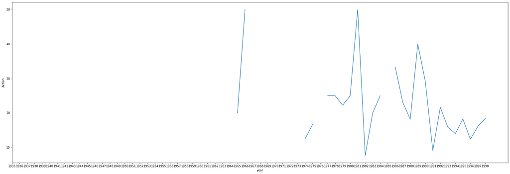

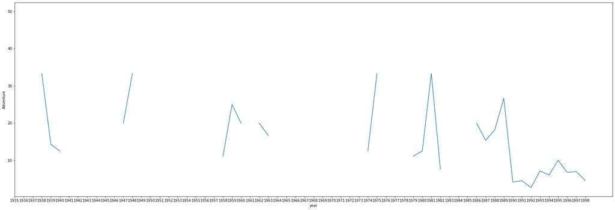

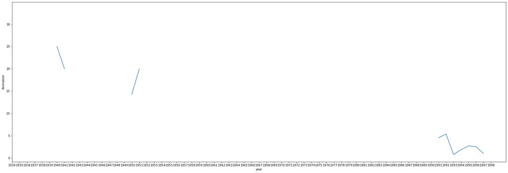

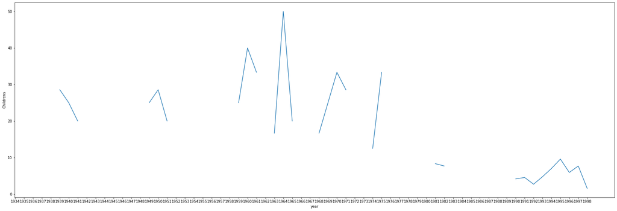

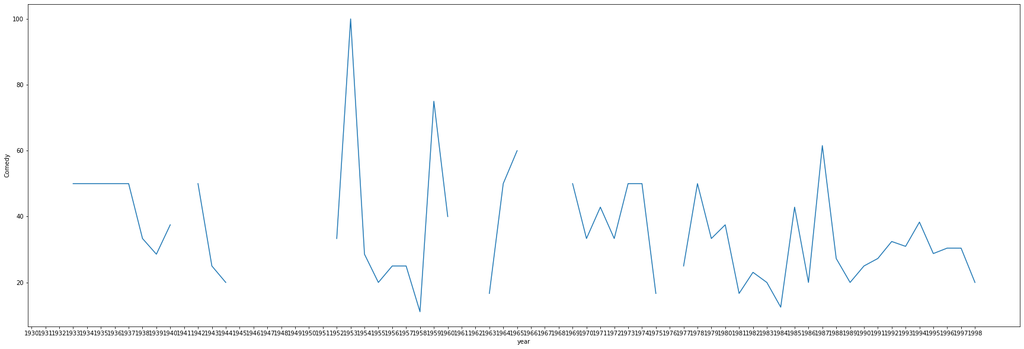

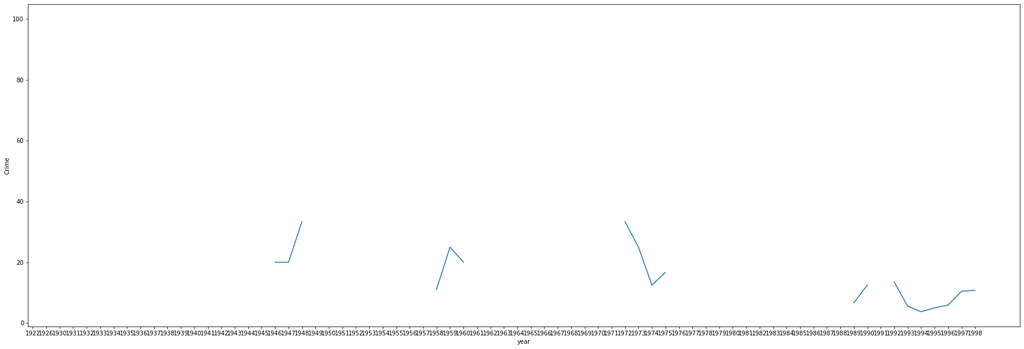

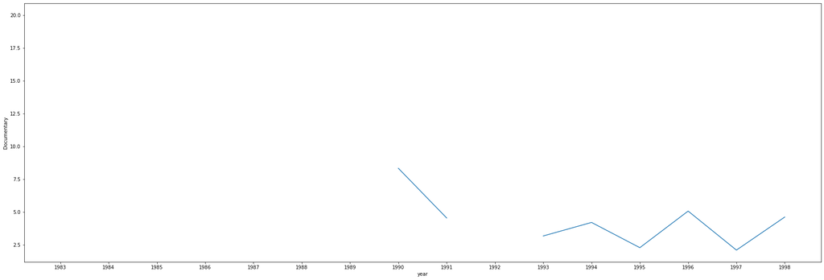

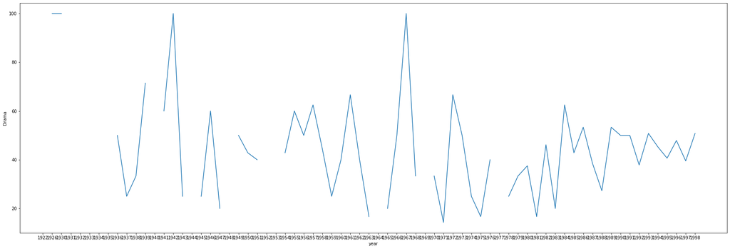

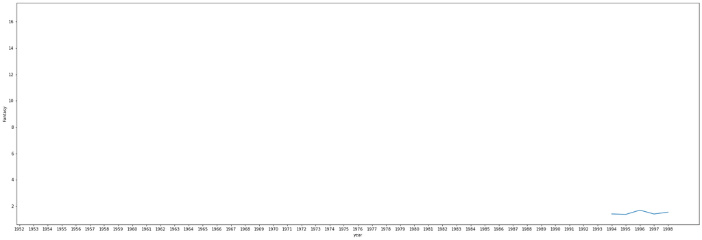

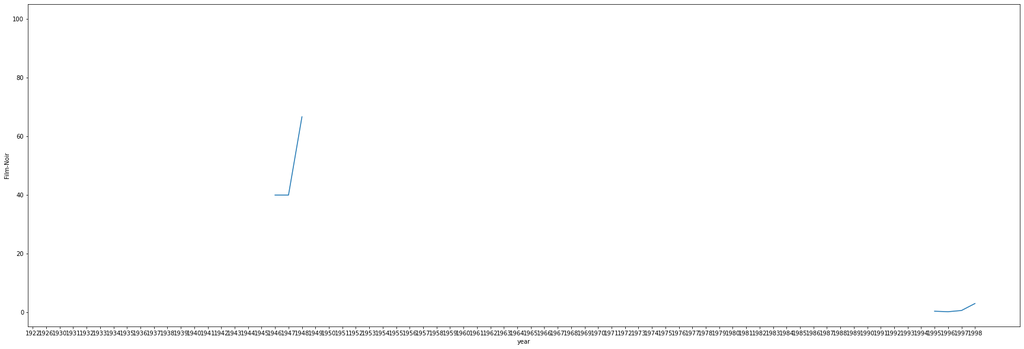

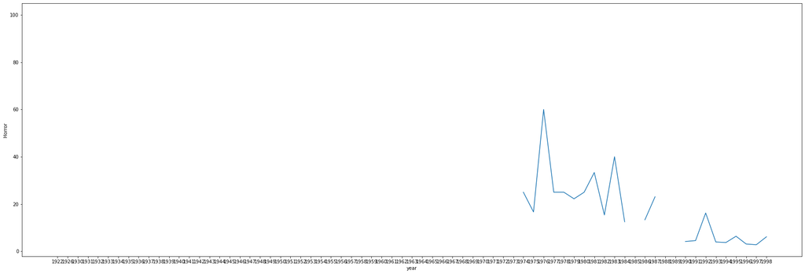

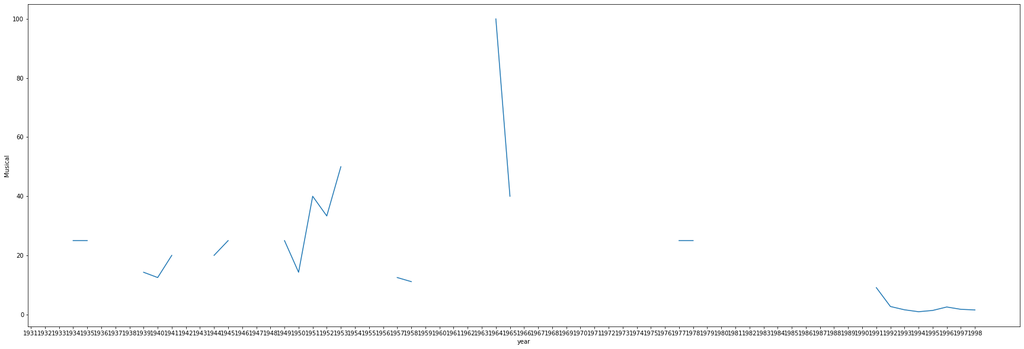

[6 more figures not shown]

```python
for (columnName, columnData) in genre_pop.iteritems():
    plt.figure(figsize=(30,10))
    if columnName not in ('year','unknown','total_movies'):
        sns.lineplot(x='year',y=columnName,data=df_percentile);
        plt.show();
```

### 9. Find the top 25 movies in terms of average ratings for movies that have been rated more than 100 times - 10 marks

Hints :

1. Find the count of ratings and average ratings for every movie.
2. Slice the movies which have ratings more than 100.
3. Sort values according to average rating such that movie which highest rating is on top.
4. Select top 25 movies.
5. You will have to use the .merge() function to get the movie titles.

Note: This question will need you to research about groupby and apply your findings. You can find more on groupby on https://realpython.com/pandas-groupby/.

```python
rating.head()
```

|  | user id | movie id | rating | timestamp |
| --- | --- | --- | --- | --- |
| 0 | 196 | 242 | 3 | 881250949 |
| 1 | 186 | 302 | 3 | 891717742 |
| 2 | 22 | 377 | 1 | 878887116 |
| 3 | 244 | 51 | 2 | 880606923 |
| 4 | 166 | 346 | 1 | 886397596 |

```python
rating['movie id'].value_counts()
```

```
50      583
258     509
100     508
181     507
294     485
       ...
1648      1
1571      1
1329      1
1457      1
1663      1
Name: movie id, Length: 1682, dtype: int64
```

```python
rating['rating'].value_counts()
```

```
4    34174
3    27145
5    21201
2    11370
1     6110
Name: rating, dtype: int64
```

```python
#count of rating for every movie
rating_counts = rating[['movie id','rating']].groupby('movie id')['rating'].count().reset_index()

rating_counts.columns = ['movie id','rating_count']
rating_counts
#rating_copy = pd.merge(rating, rating_counts, on='movie id')
#rating_copy
#rating_counts
```

|  | movie id | rating_count |
| --- | --- | --- |
| 0 | 1 | 452 |
| 1 | 2 | 131 |
| 2 | 3 | 90 |
| 3 | 4 | 209 |
| 4 | 5 | 86 |
| ... | ... | ... |
| 1677 | 1678 | 1 |
| 1678 | 1679 | 1 |
| 1679 | 1680 | 1 |
| 1680 | 1681 | 1 |
| 1681 | 1682 | 1 |

1682 rows × 2 columns

```python
#Average rating per movie
rating_avg = rating[['movie id','rating']].groupby('movie id')['rating'].mean().reset_index()
rating_avg.columns = ['movie id','rating_avg']
rating_copy=pd.merge(rating_counts, rating_avg, on='movie id')
rating_copy

#ating_avg
```

|  | movie id | rating_count | rating_avg |
| --- | --- | --- | --- |
| 0 | 1 | 452 | 3.878319 |
| 1 | 2 | 131 | 3.206107 |
| 2 | 3 | 90 | 3.033333 |
| 3 | 4 | 209 | 3.550239 |
| 4 | 5 | 86 | 3.302326 |
| ... | ... | ... | ... |
| 1677 | 1678 | 1 | 1.000000 |
| 1678 | 1679 | 1 | 3.000000 |
| 1679 | 1680 | 1 | 2.000000 |
| 1680 | 1681 | 1 | 3.000000 |
| 1681 | 1682 | 1 | 3.000000 |

1682 rows × 3 columns

```python
rating_count100 = rating_copy[rating_copy['rating_count']>100]
rating_count100
```

|  | movie id | rating_count | rating_avg |
| --- | --- | --- | --- |
| 0 | 1 | 452 | 3.878319 |
| 1 | 2 | 131 | 3.206107 |
| 3 | 4 | 209 | 3.550239 |
| 6 | 7 | 392 | 3.798469 |
| 7 | 8 | 219 | 3.995434 |
| ... | ... | ... | ... |
| 925 | 926 | 101 | 2.702970 |
| 927 | 928 | 104 | 3.115385 |
| 1015 | 1016 | 137 | 3.459854 |
| 1027 | 1028 | 148 | 3.040541 |
| 1046 | 1047 | 134 | 2.835821 |

334 rows × 3 columns

```python
rating_100sorted = rating_count100.sort_values(by=['rating_avg','rating_count'], ascending= False)
top25movie= rating_100sorted.head(25)
top25movie.shape
```

```
(25, 3)
```

```python
movie_title = movie_info[['movie id','movie title']]
top25movie = pd.merge(movie_title, top25movie,on = 'movie id' ,how = 'right')
```

### Top 25 movies

```python
top25movie['movie title']
```

```
0                                       Close Shave, A
1                                     Schindler's List
2                                  Wrong Trousers, The
3                                           Casablanca
4                            Shawshank Redemption, The
5                                          Rear Window
6                                  Usual Suspects, The
7                                            Star Wars
8                                         12 Angry Men
9                                         Citizen Kane
10                               To Kill a Mockingbird
11                     One Flew Over the Cuckoo's Nest
12                           Silence of the Lambs, The
13                                  North by Northwest
14                                      Godfather, The
15                                      Secrets & Lies
16                                   Good Will Hunting
17                           Manchurian Candidate, The
18    Dr. Strangelove or: How I Learned to Stop Worr...
19                             Raiders of the Lost Ark
20                                             Vertigo
21                                             Titanic
22                                  Lawrence of Arabia
23                                 Maltese Falcon, The
24                            Empire Strikes Back, The
Name: movie title, dtype: object
```

### 10. Check for the validity of the below statements with respect to the data provided - 10 marks

- Men watch more drama than women
- Women watch more Sci-Fi than men
- Men watch more Romance than women

**compare the percentages**

**Please pay attention to what should be the denominator while calculating percentages**

1. Merge all the datasets
2. There is no need to conduct statistical tests around this. Just **compare the percentages** and comment on the validity of the above statements.
3. you might want ot use the .sum(), .div() function here.
4. Use number of ratings to validate the numbers. For example, if out of 4000 ratings received by women, 3000 are for drama, we will assume that 75% of the women watch drama.

```python
user_rating = pd.merge(rating, user, on='user id')
user_rating
```

|  | user id | movie id | rating | timestamp | age | gender | occupation | zip code |
| --- | --- | --- | --- | --- | --- | --- | --- | --- |
| 0 | 196 | 242 | 3 | 881250949 | 49 | M | writer | 55105 |
| 1 | 196 | 393 | 4 | 881251863 | 49 | M | writer | 55105 |
| 2 | 196 | 381 | 4 | 881251728 | 49 | M | writer | 55105 |
| 3 | 196 | 251 | 3 | 881251274 | 49 | M | writer | 55105 |
| 4 | 196 | 655 | 5 | 881251793 | 49 | M | writer | 55105 |
| ... | ... | ... | ... | ... | ... | ... | ... | ... |
| 99995 | 941 | 919 | 5 | 875048887 | 20 | M | student | 97229 |
| 99996 | 941 | 273 | 3 | 875049038 | 20 | M | student | 97229 |
| 99997 | 941 | 1 | 5 | 875049144 | 20 | M | student | 97229 |
| 99998 | 941 | 294 | 4 | 875048532 | 20 | M | student | 97229 |
| 99999 | 941 | 1007 | 4 | 875049077 | 20 | M | student | 97229 |

100000 rows × 8 columns

```python
user_rat_movie = pd.merge(user_rating, movie_info, on= 'movie id')
user_rat_movie
```

|  | user id | movie id | rating | timestamp | age | gender | occupation | zip code | movie title | release date | ... | Film-Noir | Horror | Musical | Mystery | Romance | Sci-Fi | Thriller | War | Western | year |
| --- | --- | --- | --- | --- | --- | --- | --- | --- | --- | --- | --- | --- | --- | --- | --- | --- | --- | --- | --- | --- | --- |
| 0 | 196 | 242 | 3 | 881250949 | 49 | M | writer | 55105 | Kolya | 24-Jan-1997 | ... | 0 | 0 | 0 | 0 | 0 | 0 | 0 | 0 | 0 | 1997 |
| 1 | 305 | 242 | 5 | 886307828 | 23 | M | programmer | 94086 | Kolya | 24-Jan-1997 | ... | 0 | 0 | 0 | 0 | 0 | 0 | 0 | 0 | 0 | 1997 |
| 2 | 6 | 242 | 4 | 883268170 | 42 | M | executive | 98101 | Kolya | 24-Jan-1997 | ... | 0 | 0 | 0 | 0 | 0 | 0 | 0 | 0 | 0 | 1997 |
| 3 | 234 | 242 | 4 | 891033261 | 60 | M | retired | 94702 | Kolya | 24-Jan-1997 | ... | 0 | 0 | 0 | 0 | 0 | 0 | 0 | 0 | 0 | 1997 |
| 4 | 63 | 242 | 3 | 875747190 | 31 | M | marketing | 75240 | Kolya | 24-Jan-1997 | ... | 0 | 0 | 0 | 0 | 0 | 0 | 0 | 0 | 0 | 1997 |
| ... | ... | ... | ... | ... | ... | ... | ... | ... | ... | ... | ... | ... | ... | ... | ... | ... | ... | ... | ... | ... | ... |
| 99986 | 863 | 1679 | 3 | 889289491 | 17 | M | student | 60089 | B. Monkey | 06-Feb-1998 | ... | 0 | 0 | 0 | 0 | 1 | 0 | 1 | 0 | 0 | 1998 |
| 99987 | 863 | 1678 | 1 | 889289570 | 17 | M | student | 60089 | Mat' i syn | 06-Feb-1998 | ... | 0 | 0 | 0 | 0 | 0 | 0 | 0 | 0 | 0 | 1998 |
| 99988 | 863 | 1680 | 2 | 889289570 | 17 | M | student | 60089 | Sliding Doors | 01-Jan-1998 | ... | 0 | 0 | 0 | 0 | 1 | 0 | 0 | 0 | 0 | 1998 |
| 99989 | 896 | 1681 | 3 | 887160722 | 28 | M | writer | 91505 | You So Crazy | 01-Jan-1994 | ... | 0 | 0 | 0 | 0 | 0 | 0 | 0 | 0 | 0 | 1994 |
| 99990 | 916 | 1682 | 3 | 880845755 | 27 | M | engineer | N2L5N | Scream of Stone (Schrei aus Stein) | 08-Mar-1996 | ... | 0 | 0 | 0 | 0 | 0 | 0 | 0 | 0 | 0 | 1996 |

99991 rows × 30 columns

```python
user_rat_movie.columns
```

```
Index(['user id', 'movie id', 'rating', 'timestamp', 'age', 'gender',
       'occupation', 'zip code', 'movie title', 'release date', 'unknown',
       'Action', 'Adventure', 'Animation', 'Childrens', 'Comedy', 'Crime',
       'Documentary', 'Drama', 'Fantasy', 'Film-Noir', 'Horror', 'Musical',
       'Mystery', 'Romance', 'Sci-Fi', 'Thriller', 'War', 'Western', 'year'],
      dtype='object')
```

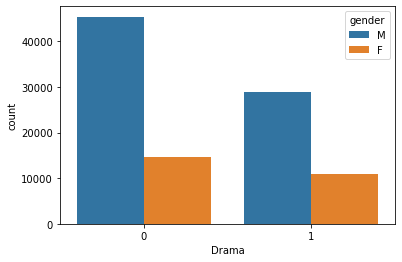

```python
sns.countplot(
    x='Drama',

    hue='gender',
    data=user_rat_movie)
```

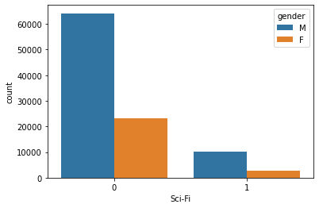

```python
sns.countplot(
    x='Sci-Fi',

    hue='gender',
    data=user_rat_movie)
```

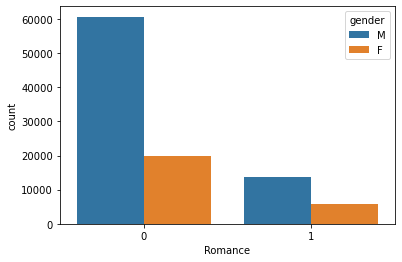

```python
sns.countplot(
    x='Romance',

    hue='gender',
    data=user_rat_movie)
```